# Custom Comparison Report: IF2 vs. DMOP

```
Report generated on: 2026-09-20 08:04:51.668186
```

# 1. Raincloud Plot of Final Log-Likelihoods (N_MONITORS=1)

This plot shows the distribution of the final evaluation pfilter log-likelihoods across the replicates for each model with $N\_MONITORS=1$.

Values filtered out (logLik < -3780):

| rep | logLik | Model |
| --- | --- | --- |
| 63 | -3820 | IF2 |
| 81 | -3789.04 | IF2 |
| 4 | -24868 | IFAD-1 |
| 8 | -3789.65 | IFAD-1 |
| 50 | -24868 | IFAD-1 |
| 76 | -24868 | IFAD-1 |
| 8 | -4201.73 | IFAD-0 |
| 76 | -24868 | IFAD-0 |

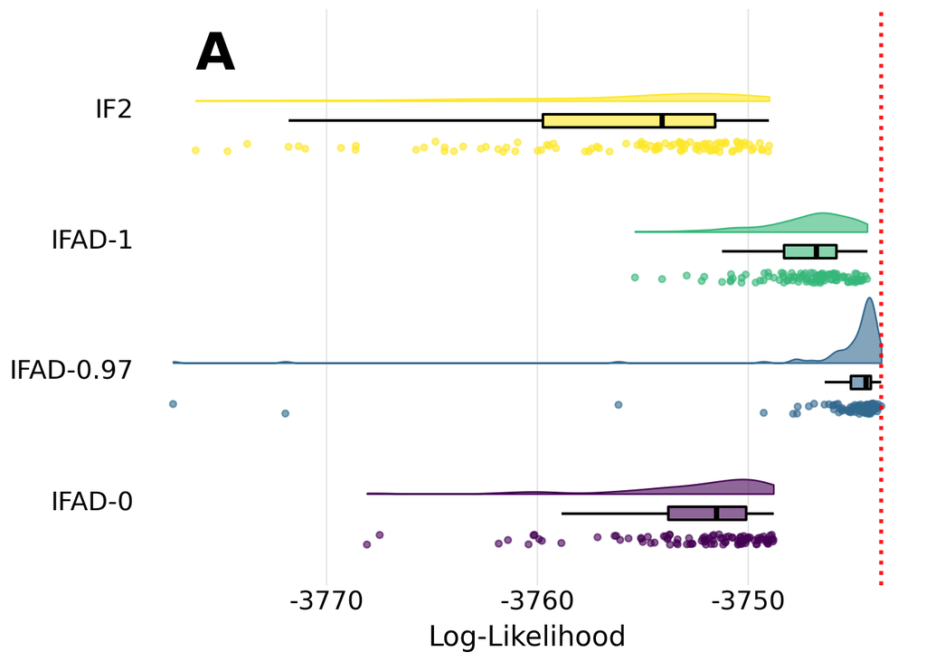

# 2. Runtime Comparison Table (N_MONITORS=0)

The table below shows the runtimes for each model component (`mif`, `train`, `pfilter`) and the total time taken for the models with $N\_MONITORS=0$.

| Model | mif (s) | train (s) | pfilter (s) | Total Time (s) |
| --- | --- | --- | --- | --- |
| IFAD-0 | 36.38 | 912.39 | 16.85 | 965.61 |
| IFAD-0.97 | 92.16 | 850.66 | 16.49 | 959.31 |
| IFAD-1 | 34.6 | 901.98 | 16.5 | 953.07 |
| IF2 | 945.9 | - | 16.54 | 962.44 |

# 3. LogLik Traces Comparison (N_MONITORS=1, Time-Scaled)

This section shows the log-likelihood search traces for the $N\_MONITORS=1$ models. The x-axis represents execution time in seconds, **scaled by the execution runtimes of their corresponding $N\_MONITORS=0$ runs**. The `mif` (IF2) part and the `train` (DMOP/training) part of each model’s trace are scaled independently by their respective $N\_MONITORS=0$ component runtimes.

```
Dropped 200 rows with NaN logLik for IFAD-0:
method  iteration  rep  logLik
   mif          0    0     NaN
 train         60    0     NaN
   mif          0    1     NaN
 train         60    1     NaN
   mif          0    2     NaN
...
  - 0 of these did not occur at iteration 0 or transition iteration 60.
Dropped 200 rows with NaN logLik for IFAD-0.97:
method  iteration  rep  logLik
   mif          0    0     NaN
 train        175    0     NaN
   mif          0    1     NaN
 train        175    1     NaN
   mif          0    2     NaN
...
  - 0 of these did not occur at iteration 0 or transition iteration 175.
Dropped 200 rows with NaN logLik for IFAD-1:
method  iteration  rep  logLik
   mif          0    0     NaN
 train         60    0     NaN
   mif          0    1     NaN
 train         60    1     NaN
   mif          0    2     NaN
...
  - 0 of these did not occur at iteration 0 or transition iteration 60.
Dropped 100 rows with NaN logLik for IF2:
method  iteration  rep  logLik
   mif          0    0     NaN
   mif          0    1     NaN
   mif          0    2     NaN
   mif          0    3     NaN
   mif          0    4     NaN
...
  - 0 of these did not occur at iteration 0 or transition iteration 1950.
```

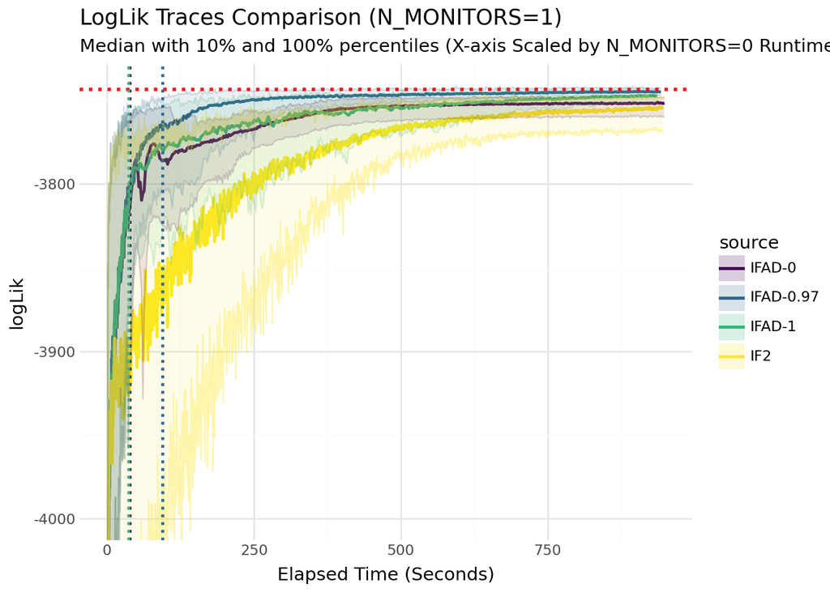

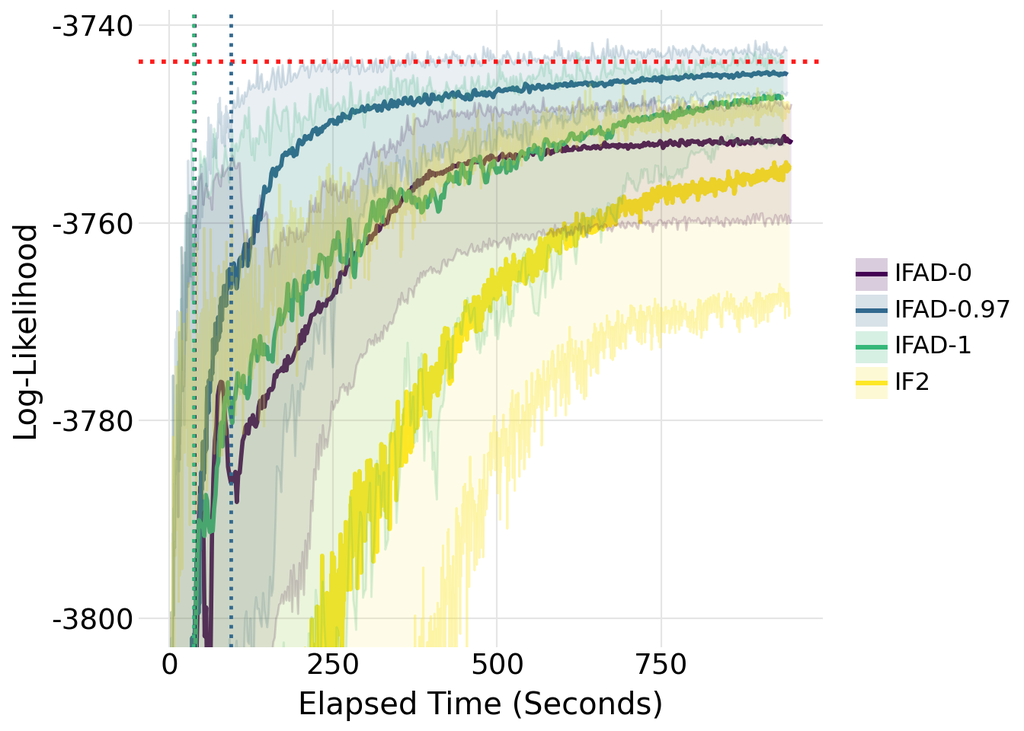

Summary Statistics for N_MONITORS=1 Models

| Model | Final Median LogLik | Final Max LogLik |
| --- | --- | --- |
| IFAD-0 | -3751.60 | -3747.99 |
| IFAD-0.97 | -3745.04 | -3742.56 |
| IFAD-1 | -3747.30 | -3743.18 |
| IF2 | -3754.19 | -3748.06 |

# 4. Parameter Estimate Density Plots (N_MONITORS=1)

This section shows density plots of final parameter estimates across the replicates for each model with $N\_MONITORS=1$. Dotted red lines represent the default parameters.

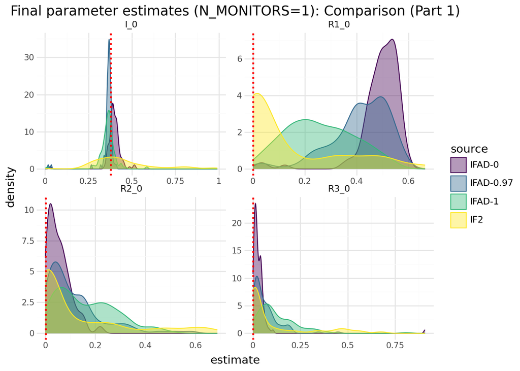

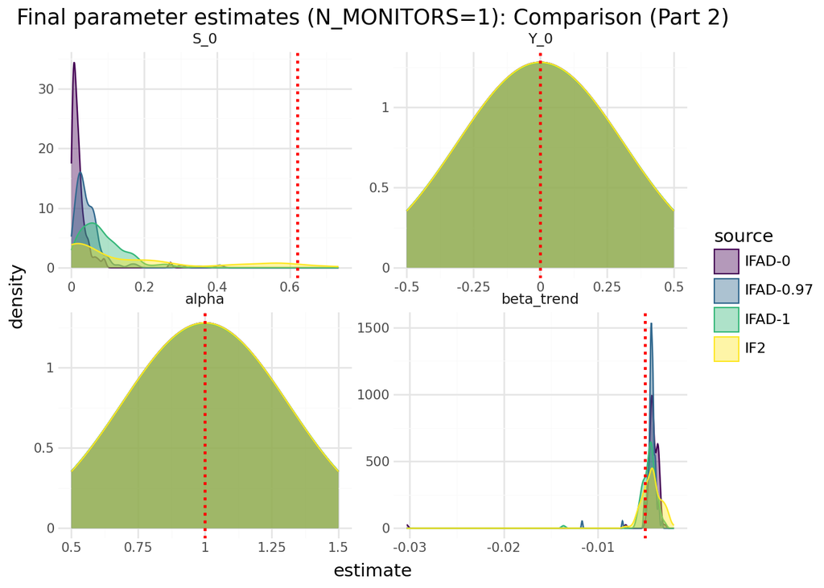

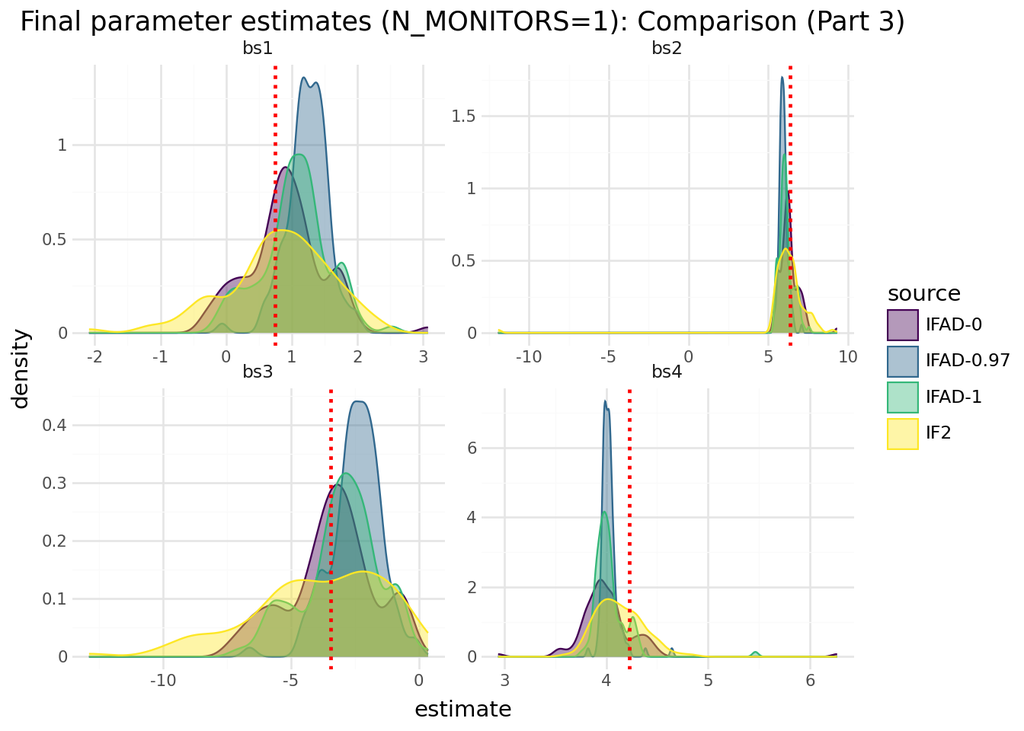

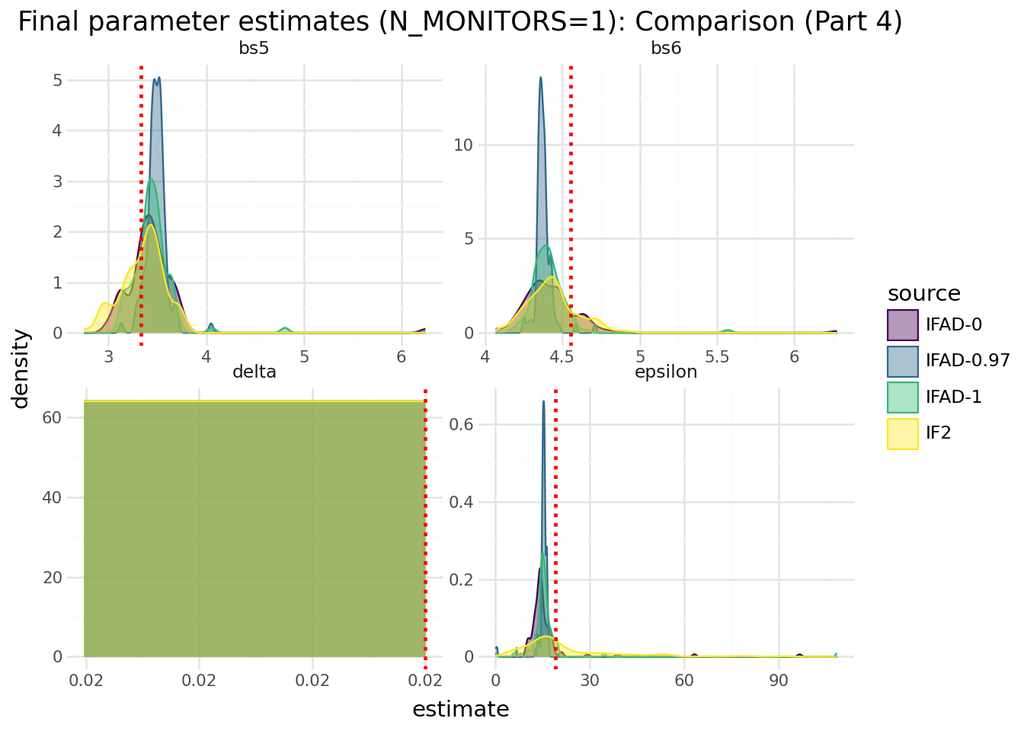

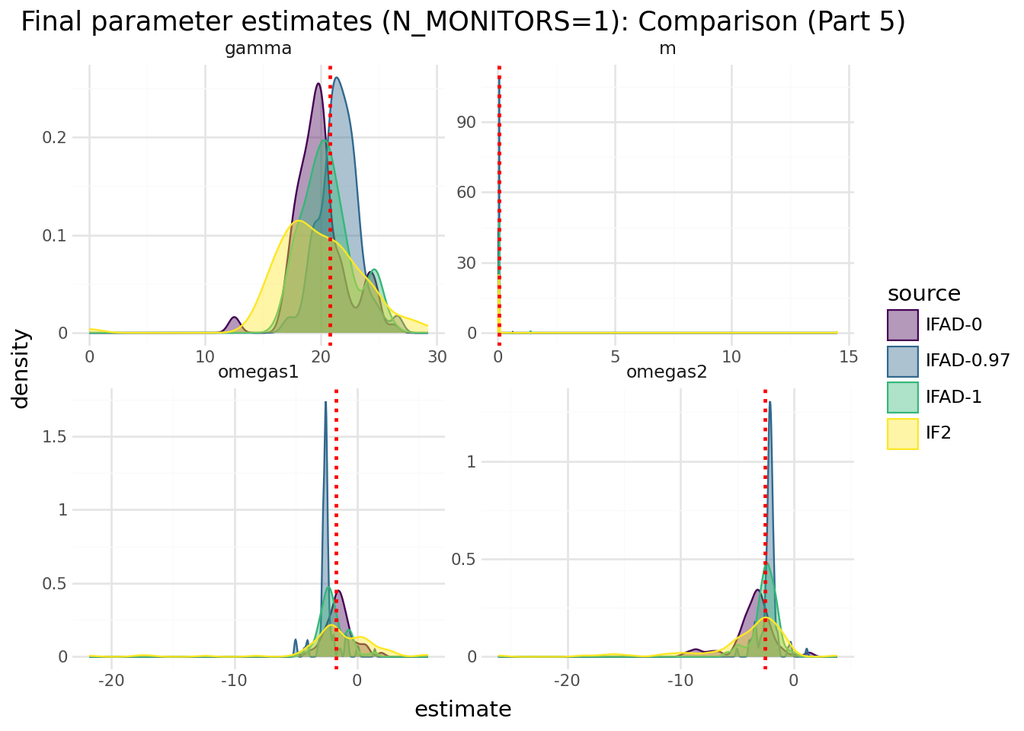

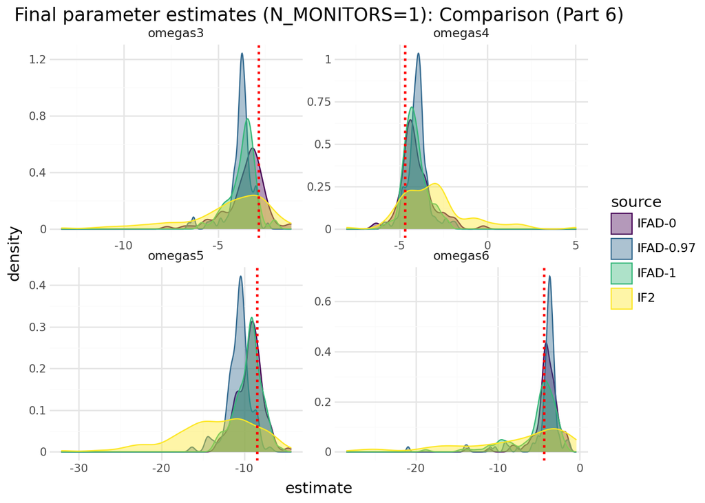

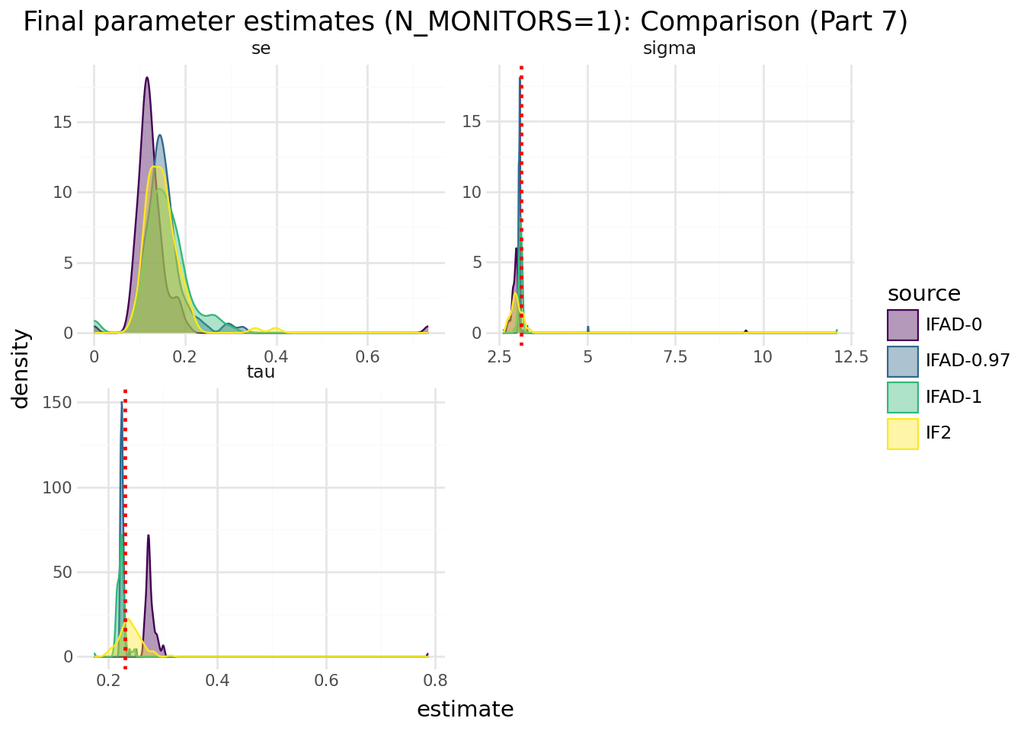

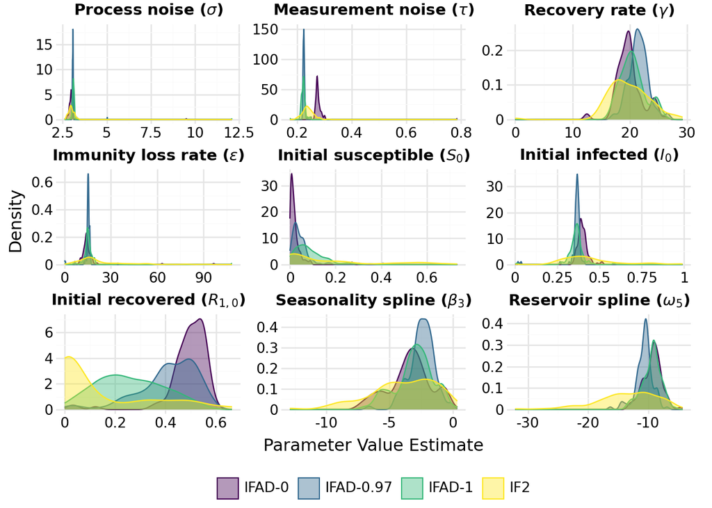

# 5. Best Log-Likelihoods (N_MONITORS=0 & N_MONITORS=1)

This section displays the log-likelihood statistics obtained from the final pfilter evaluations across the replicates for both the $N\_MONITORS=0$ and $N\_MONITORS=1$ runs.

To ensure consistency and transparency, we report: 1. **Best LogLik (Post-Pruned, index=-1)**: The fresh, unbiased evaluation of the single selected best replicate.

2. **Best LogLik (Pre-Pruned, index=-2)**: The maximum evaluation among all 100 replicates before pruning. (Note: Due to selection bias/the winner’s curse and particle filter stochasticity, the maximum value in `index=-2` may appear slightly higher than the fresh evaluation in `index=-1`).
3. **Median LogLik (Pre-Pruned, index=-2)**: The median evaluation across all 100 replicates.
4. **Variance LogLik (Pre-Pruned, index=-2)**: The variance of evaluations across all 100 replicates before pruning.

### N_MONITORS = 0 Models

| Model | Best LogLik (Post-Pruned, index=-1) | Best LogLik (Pre-Pruned, index=-2) | Median LogLik (Pre-Pruned, index=-2) | Variance LogLik (Pre-Pruned, index=-2) |
| --- | --- | --- | --- | --- |
| IFAD-0 | -3748.68 | -3748.48 | -3752.23 | 8.82344e+06 |
| IFAD-0.97 | -3744.23 | -3743.77 | -3744.46 | 9.56 |
| IFAD-1 | -3744.64 | -3744.45 | -3747.22 | 1.72978e+07 |
| IF2 | -3748.84 | -3748.76 | -3754.22 | 93.42 |

### N_MONITORS = 1 Models

| Model | Best LogLik (Post-Pruned, index=-1) | Best LogLik (Pre-Pruned, index=-2) | Median LogLik (Pre-Pruned, index=-2) | Variance LogLik (Pre-Pruned, index=-2) |
| --- | --- | --- | --- | --- |
| IFAD-0 | -3749.02 | -3748.8 | -3751.62 | 4.45873e+06 |
| IFAD-0.97 | -3744.26 | -3743.68 | -3744.4 | 19.86 |
| IFAD-1 | -3744.4 | -3744.36 | -3746.84 | 1.31116e+07 |
| IF2 | -3748.97 | -3749 | -3754.24 | 93.25 |